# Practical Machine Learning Course Project

## Executive Summary

In this project, I first perform some exploratory analysis to the dataset and clean some of them with unimportant information or with too many NA. Then I apply 2 machine learning algorithm on training set and calculate accuracy through cross validation. The result shows that random forest produces the highest accuracy, so I apply it on test set to classify them.

## Downloading Data

```r
download.file("https://d396qusza40orc.cloudfront.net/predmachlearn/pml-training.csv", destfile = "training.csv")
download.file("https://d396qusza40orc.cloudfront.net/predmachlearn/pml-testing.csv", destfile = "testing.csv")
```

## Getting and Cleaning Data

```r
Training <- read.csv("training.csv", header = TRUE)
Testing <- read.csv("testing.csv", header = TRUE)
dim(Training)
```

```
## [1] 19622   160
```

```r
dim(Testing)
```

```
## [1]  20 160
```

The first 2 columns represents the name of people, columns 3-5 represents timestamp, columns 6-7 have nothing to do with the way performing barbell lifts, so I remove them from the dataset.

```r
TrainingClean <- Training[, -c(1:7)]
TestingClean <- Testing[, -c(1:7)]
```

There are many NA in the dataset, so I remove the columns with the majority being NA.

```r
library(caret)
TrainingClean <- TrainingClean[, colSums(is.na(TrainingClean)) == 0]
TestingClean <- TestingClean[, colSums(is.na(TestingClean)) == 0]
removeNA <- nearZeroVar(TrainingClean)
TrainingClean <- TrainingClean[, -removeNA]
dim(TrainingClean)
```

```
## [1] 19622    53
```

```r
str(TrainingClean)
```

```
## 'data.frame':    19622 obs. of  53 variables:
##  $ roll_belt           : num  1.41 1.41 1.42 1.48 1.48 1.45 1.42 1.42 1.43 1.45 ...
##  $ pitch_belt          : num  8.07 8.07 8.07 8.05 8.07 8.06 8.09 8.13 8.16 8.17 ...
##  $ yaw_belt            : num  -94.4 -94.4 -94.4 -94.4 -94.4 -94.4 -94.4 -94.4 -94.4 -94.4 ...
##  $ total_accel_belt    : int  3 3 3 3 3 3 3 3 3 3 ...
##  $ gyros_belt_x        : num  0 0.02 0 0.02 0.02 0.02 0.02 0.02 0.02 0.03 ...
##  $ gyros_belt_y        : num  0 0 0 0 0.02 0 0 0 0 0 ...
##  $ gyros_belt_z        : num  -0.02 -0.02 -0.02 -0.03 -0.02 -0.02 -0.02 -0.02 -0.02 0 ...
##  $ accel_belt_x        : int  -21 -22 -20 -22 -21 -21 -22 -22 -20 -21 ...
##  $ accel_belt_y        : int  4 4 5 3 2 4 3 4 2 4 ...
##  $ accel_belt_z        : int  22 22 23 21 24 21 21 21 24 22 ...
##  $ magnet_belt_x       : int  -3 -7 -2 -6 -6 0 -4 -2 1 -3 ...
##  $ magnet_belt_y       : int  599 608 600 604 600 603 599 603 602 609 ...
##  $ magnet_belt_z       : int  -313 -311 -305 -310 -302 -312 -311 -313 -312 -308 ...
##  $ roll_arm            : num  -128 -128 -128 -128 -128 -128 -128 -128 -128 -128 ...
```

[output cut: 39 more lines]

```r
dim(TestingClean)
```

```
## [1] 20 53
```

```r
str(TestingClean)
```

```
## 'data.frame':    20 obs. of  53 variables:
##  $ roll_belt           : num  123 1.02 0.87 125 1.35 -5.92 1.2 0.43 0.93 114 ...
##  $ pitch_belt          : num  27 4.87 1.82 -41.6 3.33 1.59 4.44 4.15 6.72 22.4 ...
##  $ yaw_belt            : num  -4.75 -88.9 -88.5 162 -88.6 -87.7 -87.3 -88.5 -93.7 -13.1 ...
##  $ total_accel_belt    : int  20 4 5 17 3 4 4 4 4 18 ...
##  $ gyros_belt_x        : num  -0.5 -0.06 0.05 0.11 0.03 0.1 -0.06 -0.18 0.1 0.14 ...
##  $ gyros_belt_y        : num  -0.02 -0.02 0.02 0.11 0.02 0.05 0 -0.02 0 0.11 ...
##  $ gyros_belt_z        : num  -0.46 -0.07 0.03 -0.16 0 -0.13 0 -0.03 -0.02 -0.16 ...
##  $ accel_belt_x        : int  -38 -13 1 46 -8 -11 -14 -10 -15 -25 ...
##  $ accel_belt_y        : int  69 11 -1 45 4 -16 2 -2 1 63 ...
##  $ accel_belt_z        : int  -179 39 49 -156 27 38 35 42 32 -158 ...
##  $ magnet_belt_x       : int  -13 43 29 169 33 31 50 39 -6 10 ...
##  $ magnet_belt_y       : int  581 636 631 608 566 638 622 635 600 601 ...
##  $ magnet_belt_z       : int  -382 -309 -312 -304 -418 -291 -315 -305 -302 -330 ...
##  $ roll_arm            : num  40.7 0 0 -109 76.1 0 0 0 -137 -82.4 ...
```

[output cut: 39 more lines]

After data cleaning, there are 53 variables in training set and testing set.

## Preprocessing Data for Modeling

```r
set.seed(2333)
inTrain <- createDataPartition(TrainingClean$classe, p = 0.70, list = FALSE)
trainData <- TrainingClean[inTrain, ]
testData <- TrainingClean[-inTrain, ]
```

## Exploratory Data Analysis

To find out variables in the training dataset with high correlation, I draw a correlation map among them.

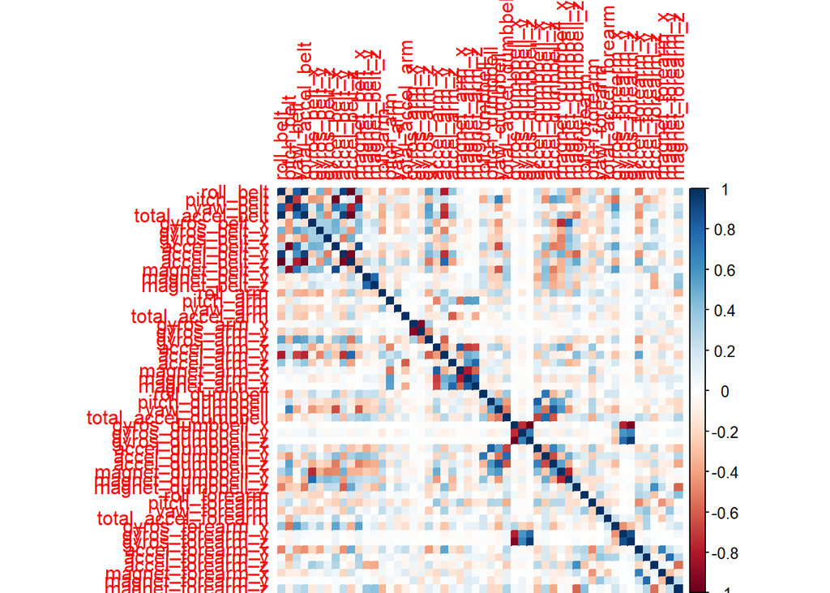

```r
library(corrplot)
CorrMap <- cor(trainData[, -length(names(trainData))])
corrplot(CorrMap, method = "color")
```

```r
highCorr <- findCorrelation(CorrMap, cutoff = 0.70)
names(trainData)[highCorr]
```

```
##  [1] "accel_belt_z"      "roll_belt"         "accel_belt_y"
##  [4] "accel_arm_y"       "total_accel_belt"  "yaw_belt"
##  [7] "accel_dumbbell_z"  "accel_belt_x"      "pitch_belt"
## [10] "magnet_dumbbell_x" "accel_dumbbell_y"  "magnet_dumbbell_y"
## [13] "accel_dumbbell_x"  "accel_arm_x"       "accel_arm_z"
## [16] "magnet_arm_y"      "magnet_belt_z"     "accel_forearm_y"
## [19] "gyros_forearm_y"   "gyros_dumbbell_x"  "gyros_dumbbell_z"
## [22] "gyros_arm_x"
```

There are 22 variables highly correlated with each other.

# classification tree

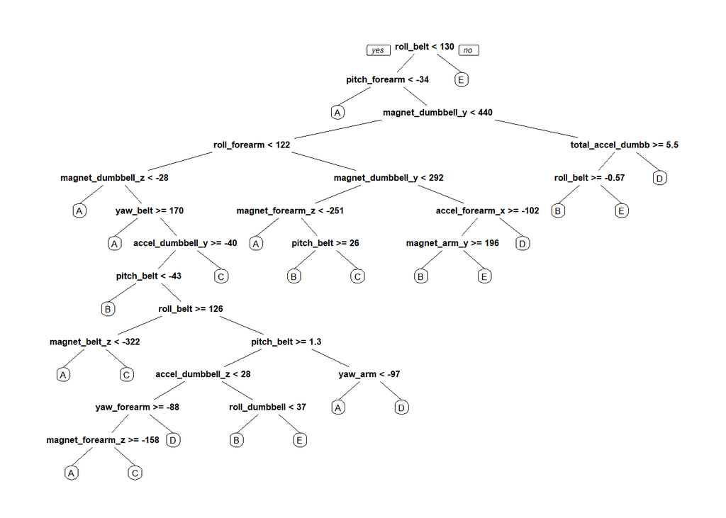

```r
library(rpart)
library(rpart.plot)
trControl <- trainControl(method = "cv", 5)
ModTree <- train(classe ~., data = trainData, method = "rpart", trControl = trControl)
treeModel <- rpart(classe ~., data = trainData, method = "class")
prp(treeModel)
```

```r
TreePred <- predict(ModTree, testData)
confusionMatrix(testData$classe, TreePred)
```

```
## Confusion Matrix and Statistics
##
##           Reference
## Prediction    A    B    C    D    E
##          A 1520   24  127    0    3
##          B  452  403  284    0    0
##          C  483   33  510    0    0
##          D  408  166  390    0    0
##          E  166  145  290    0  481
##
## Overall Statistics
##
##                Accuracy : 0.4952
##                  95% CI : (0.4823, 0.508)
##     No Information Rate : 0.5147
##     P-Value [Acc > NIR] : 0.9987
##
##                   Kappa : 0.3407
##  Mcnemar's Test P-Value : NA
##
## Statistics by Class:
##
##                      Class: A Class: B Class: C Class: D Class: E
## Sensitivity            0.5018  0.52270  0.31855       NA  0.99380
## Specificity            0.9461  0.85608  0.87955   0.8362  0.88872
## Pos Pred Value         0.9080  0.35382  0.49708       NA  0.44455
## Neg Pred Value         0.6417  0.92246  0.77547       NA  0.99938
## Prevalence             0.5147  0.13101  0.27205   0.0000  0.08224
## Detection Rate         0.2583  0.06848  0.08666   0.0000  0.08173
## Detection Prevalence   0.2845  0.19354  0.17434   0.1638  0.18386
## Balanced Accuracy      0.7239  0.68939  0.59905       NA  0.94126
```

Classification Tree gets accuracy of only 0.4952, it is a poor model, so I should try another model.

# Random Forest

```r
trControl <- trainControl(method = "cv", 5)
ModRf <- train(classe ~., data = trainData, method = "rf", trControl = trControl, verbose = FALSE)
ModRf
```

```
## Random Forest
##
## 13737 samples
##    52 predictor
##     5 classes: 'A', 'B', 'C', 'D', 'E'
##
## No pre-processing
## Resampling: Cross-Validated (5 fold)
## Summary of sample sizes: 10990, 10990, 10989, 10990, 10989
## Resampling results across tuning parameters:
##
##   mtry  Accuracy   Kappa
##    2    0.9912651  0.9889498
##   27    0.9902456  0.9876595
##   52    0.9848590  0.9808436
##
## Accuracy was used to select the optimal model using  the largest value.
## The final value used for the model was mtry = 2.
```

## Predicting Data

```r
result <- predict(ModRf, TestingClean[, -length(names(TestingClean))])
result
```

```
##  [1] B A B A A E D B A A B C B A E E A B B B
## Levels: A B C D E
```